# zagadnienie_wlasne_2

## Zagadnienie własne - kwantowy oscylator harmoniczny

Rozwiążemy równanie Schrodingera dla kwantowego oscylatora harmonicznego

\begin{equation} \label{Sch_oh} -\frac{1}{2}\frac{d^2\psi}{dx^2} +\frac{x^2}{2}\psi(x)=\epsilon\psi(x) \end{equation}

metodą różnic skończonych.

Wybierzemy $x=a$ takie, że funkcja falowa $\psi(\pm a)$ jest na tyle mała by przyjąć, że znika w $x=\pm a$.

Przedział [-a,a] podzielimy na n+1 punktów

\begin{equation} \label{eq:moh} x_i = -a +ih;\;\;h=\frac{2a}{n}, \;\; i=0,1,\ldots,n \end{equation}

Drugą pochodną $ \psi_i^{\prime\prime}\equiv \psi^{\prime\prime}(x_i)$ przybliżymy róznicami skończonymi

\begin{equation} \label{eq:poch2} \psi_i^{\prime\prime}=\frac{\psi_{i-1}-2\psi_{i}+\psi_{i+1} }{ h^2} \end{equation}

gdzie $\psi_i\equiv \psi(x_i)$.

Równanie (\ref{Sch_oh}) zastąpimy n-1 równaniami na $\psi_1,\psi_2,\ldots,\psi_{n-1}$ i $\epsilon$

\begin{equation} -\frac{\psi_{i-1}-2\psi_{i}+\psi_{i+1} }{2 h^2}+\frac{x_i^2}{2}\psi_{i}= \epsilon\psi_{i},\;\;\; i=1,2,\dots,n-1 \end{equation}

Uwzględniając warunki brzegowe $\psi_0=0,\;\;\psi_n=0$ dostaniemy te równania w postaci

pierwsze ($i=1$)

\begin{equation} \left(\frac{1}{h^2}+\frac{x_1^2}{2}\right)\psi_{1} -\frac{1}{2h^2}\psi_{2} =\epsilon\psi_{1} \end{equation}

wewnętrzne ($1<i<n-1$)

\begin{equation} -\frac{1}{2h^2}\psi_{i-1} +\left(\frac{1}{h^2}+\frac{x_i^2}{2}\right)\psi_{i} -\frac{1}{2h^2}\psi_{i+1} =\epsilon\psi_{i} \end{equation}

ostatnie ($i=n-1$)

\begin{equation} -\frac{1}{2h^2}\psi_{n-2} +\left(\frac{1}{h^2}+\frac{x_{n-1}^2}{2}\right)\psi_{n-1} =\epsilon\psi_{n-1} \end{equation}

Macierzowy zapis tych równań

\begin{equation} \label{mac_row} \mathbb{H}\mathbb{v}=\epsilon\mathbb{v} \end{equation}

pokazuje, że sprowadziliśmy rozwiązanie równania Shrodingera (\ref{Sch_oh}) do zagadnienia własnego macierzy

\begin{equation} \label{eq:macH} \mathbb{H}=\left(\begin{matrix} d_1 & g & 0 & 0 &0 & \cdots & 0\\ g & d_2 & g & 0 &0 & \cdots & 0\\ 0 & g & d_3 & g &0 & \cdots & 0\\ & & \ddots& \ddots& \ddots & & \\ 0 & \cdots &0 & g & d_{n-3} & g& 0\\ 0 & \cdots & 0 &0 & g & d_{n-2} & g\\ 0 & \cdots & 0 &0 & 0 & g & d_{n-1} \end{matrix}\right) \end{equation}

gdzie $$ g= -\frac{1}{2h^2},\;\;\;d_{i}=\left(\frac{1}{h^2}+\frac{x_i^2}{2}\right) $$

$$ \mathbb{v}=\left(\psi_{1},\psi_{2},\ldots,\psi_{n-1}\right)^T $$

Innymi słowy, wartości własne macierzy (\ref{eq:macH}) są energiami własnymi, a wektory własne nieunormowanymi funkcjami falowymi oscylatora harmonicznego

### Wartości i wektory własne macierzy rzadkich

Ponieważ $\mathbb{H}$ jest macierzą rzadką (większość jej składowych jest zerowa) wykorzystamy moduł scipy.sparse.linalg do diagonalizacji tej macierzy. Dzięki temu będziemy mogli wykonać obliczenia dla bardzo dużych n, aż do $10^7$.

Do diagonalizacji macierzy rzadkiej A, symetrycznej lub hermitowskiej, przeznaczona jest funkcja

scipy.sparse.linalg.eigsh(A, k=6, M=None, sigma=None, which='LM',...)

obliczająca k wartości i wektorów własnych. Opcja which wskazuje, które wartości będą obliczone:'LM' - największe co do wielkości, 'SM' - najmniejsze co do wielkości, itd.

Do obliczania najmniejszych wartości wasnych w pobliżu r, rekomendowane jest ustawienie sigma=r i which='LM'

https://docs.scipy.org/doc/scipy/reference/generated/scipy.sparse.linalg.eigsh.html#scipy.sparse.linalg.eigsh

```python
import numpy as np
from scipy.sparse import diags
from scipy.sparse.linalg import eigsh
# punkt brzegowy a
a=7.0
n=100000 # możemy wziąć n=10**7 !!!
# krok - stała sieci
h=2*a/n
# elementy diagonalne jest ich n-1
d=np.fromfunction(lambda i:1/h**2+0.5*(-a+(i+1)*h)**2 ,(n-1,),dtype=float)
# elementy nad/pod przekątną jest ich n-2
g= -0.5/h**2*np.ones(n-2)
#
data=[d.tolist(),g.tolist(),g.tolist()]
positions=[0,1,-1]
# tworzenie macierzy rzadkiej za pomocą funkcji diags()
# wybieramy  format csc preferowany przez eigsh() z opcją sigma
Hm=diags(data,positions,(n-1,n-1)).tocsc()

#obliczymy 4 wartości własne k=4 leżace najbliżej sigma=0
# użycie opcji sigma wymaga ustawienia which='LM'
#
eH,vH=eigsh(Hm,k=4,sigma=0.0,which='LM')
#
# eH,vH=eigsh(Hm,k=4,which='SM') to jest bardzo wolna opcja: n=10000 liczy kilka minut
print('wartości własne\n')
print(eH)
```

```
wartości własne

[0.5        1.5        2.49999999 3.49999998]
```

Porównanie tych wyników z dokładnymi energiami oscylatora harmonicznego

\begin{equation} \label{e_wlasne} \epsilon_i=i+\frac{1}{2},\;\;\;\; i=0,1,2,\ldots \end{equation}

pokazuje dużą dokładnością obliczeń.

### Funkcje falowe

Wykreślimy teraz funkcje falowe związane z wartościami własnymi (\ref{e_wlasne}). Jednak, wcześniej musimy je unormować. W tym przypadku, mamy równoodległe punkty $x_i$, więc możemy skorzystać ze złożonego wzoru trapezów do obliczenia całki

\begin{equation} \label{eq:calka} \int_{-a}^{a}{|\psi(x)|^2 dx} \end{equation}

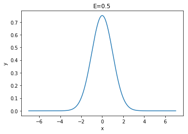

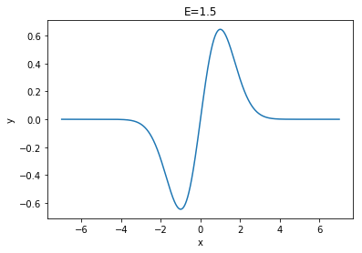

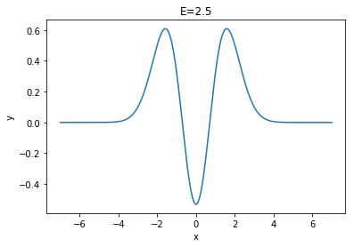

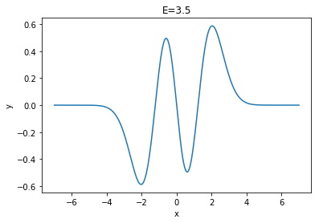

```python
%matplotlib  inline
import matplotlib.pyplot as plt
xx=np.arange(h-a,a-h+1e-12,h)
for i in range(4):
    nv=1/np.sqrt((h*(vH[:,i]**2)).sum())  #normowanie
    plt.plot(xx, nv*vH[:,i])
    tyt='E='+str(round(eH[i],2))
    plt.xlabel('x')
    plt.ylabel('y')
    plt.title(tyt)
    plt.show()
```

### Zależność dokładności obliczeń energii od liczby punktów

```python
# Sprawdzimy jak precyzja obliczeń energii własnych zależy od n

import time
er=[0.5,1.5,2.5,3.5]
a=7.0
n=10
for _ in range(6):
    start=time.time()
    n*=10
    h=2*a/n
    d=np.fromfunction(lambda i:1/h**2+0.5*(-a+(i+1)*h)**2 ,(n-1,),dtype=float)
    g= -0.5/h**2*np.ones(n-2)
    Hm=diags([d.tolist(),g.tolist(),g.tolist()],[0,1,-1],(n-1,n-1)).tocsc()
    eH,vH=eigsh(Hm,k=4,sigma=0.0,which='LM')
    pr=eH-er
    end=time.time()
    cz=end-start
    # wydrukujemy odchylenia od dokładnych wyników i czas obliczeń
    print("n=%8d  %10.3e  %10.3e  %10.3e  %10.3e  t=%8.2f"\
          %(n,pr[0],pr[1],pr[2],pr[3],cz))
```

```
n=     100  -6.133e-04  -3.069e-03  -7.989e-03  -1.538e-02  t=    0.01
n=    1000  -6.125e-06  -3.063e-05  -7.963e-05  -1.531e-04  t=    0.02
n=   10000  -6.125e-08  -3.062e-07  -7.962e-07  -1.531e-06  t=    0.06
n=  100000  -6.666e-10  -3.118e-09  -7.992e-09  -1.533e-08  t=    0.62
n= 1000000   1.851e-10   1.035e-10  -7.023e-10   9.524e-11  t=    5.34
n=10000000  -1.125e-07  -2.963e-08  -7.540e-08  -2.670e-08  t=   47.82
```

10-krotne zwiększenie rozmiaru siatki poprawia wynik o 2 rzędy. Takie zachowanie wynika z faktu, że krok $h=\frac{2a}{n}$zależy od n, a przybliżenie drugiej pochodnej za pomocą różnicy centralnej jest rzędu $h^2$.

Widzimy, że najlepsze wyniki otrzymujemy dla n równego milion, co jest związane z optymalną wielkością h do obliczania drugiej pochodnej.

### Zależność dokładności obliczeń energii od szerkości przedziału

```python
# Sprawdzimy jak precyzja obliczeń energi własnych zależy od szerokości przedziału
# [-a,a], czyli od  a
n=1000000
for a in np.arange(4,10,0.5):
    h=2*a/n
    d=np.fromfunction(lambda i:1/h**2+0.5*(-a+(i+1)*h)**2 ,(n-1,),dtype=float)
    g= -0.5/h**2*np.ones(n-2)
    Hm=diags([d.tolist(),g.tolist(),g.tolist()],[0,1,-1],(n-1,n-1)).tocsc()
    eH,vH=eigsh(Hm,k=4,sigma=0.0,which='LM')
    pr=eH-er
    # wydrukujemy odchylenia wartości własnych od dokładnych wyników
    # w ostatniej kolumnie drukujemy wartość czwartego wektora vH na prawym końcu
    print("a=%8.4f  %10.3e  %10.3e  %10.3e  %10.3e | %10.3e" \
          %(a,pr[0],pr[1],pr[2],pr[3],vH[-1,3] ) )
```

```
a=  4.0000   4.892e-07   1.460e-05   2.012e-04   1.692e-03 | -2.268e-09
a=  4.5000   4.613e-09   3.023e-07   5.502e-06   6.231e-05 |  5.738e-10
a=  5.0000  -4.721e-09   2.476e-09   8.282e-08   1.220e-06 |  1.017e-10
a=  5.5000  -1.106e-09  -1.103e-09   2.234e-11   1.260e-08 | -1.301e-11
a=  6.0000   1.251e-09   7.931e-10   2.757e-10   3.259e-10 | -1.223e-12
a=  6.5000   5.711e-10   1.873e-09   1.347e-09   1.179e-09 | -8.553e-14
a=  7.0000   1.851e-10   1.034e-10  -7.023e-10   9.522e-11 | -4.482e-15
a=  7.5000  -9.933e-11  -7.041e-10   3.958e-10   1.489e-10 |  1.772e-16
a=  8.0000  -8.118e-11   6.941e-10   6.582e-10   1.128e-10 |  5.349e-18
a=  8.5000  -6.839e-10  -5.785e-10  -7.894e-10  -3.390e-10 | -2.437e-19
a=  9.0000  -2.216e-10  -3.978e-11   2.144e-11  -3.326e-11 |  6.405e-20
a=  9.5000   1.265e-10   1.021e-09   5.786e-10   6.559e-10 | -6.416e-20
```

Wyniki tego testu pokazują, że wartość parametru a nie powinna być mniejsza od 5. Dla $a>5.5$ dokładność pierwszych czterech wartości własnych pozostaje prawie stała. Widzimy też jak wartość parametru a wpływa na wartość funkcji falowej na prawym końcu.

Rozwiążemy jeszcze to zagadnienie własne za pomocą metod dla"gęstych" macierzy, żeby pokazać ich małą przydatność do tego typu zadań. Wykorzystamy funkcję eigh_tridiagonal() z scipy.linalg

```python
# Sprawdzimy obliczanie wartości własnych dla gęstych macierzy
from scipy.linalg import eigh_tridiagonal
er=np.array([0.5,1.5,2.5,3.5])
start=time.time()
a =7.0

n=10
for _ in range(4):
    start=time.time()
    n*=10
    h=2*a/n
    d=np.fromfunction(lambda i:1/h**2+0.5*(-a+(i+1)*h)**2 ,(n-1,),dtype=float)
    g= -0.5/h**2*np.ones(n-2)
    wah,vah=eigh_tridiagonal(d,g)

    pr=wah[:4] -er
    end=time.time()
    cz=end-start
    # wydrukujemy odchylenia od dokładnych wyników i czas obliczeń
    print("n=%8d  %10.3e  %10.3e  %10.3e  %10.3e  t=%8.2f"\
          %(n,pr[0],pr[1],pr[2],pr[3],cz))
```

```
n=     100  -6.133e-04  -3.069e-03  -7.989e-03  -1.538e-02  t=    0.00
n=    1000  -6.125e-06  -3.063e-05  -7.963e-05  -1.531e-04  t=    0.11
n=   10000  -6.131e-08  -3.063e-07  -7.963e-07  -1.531e-06  t=   19.87
```

[output not shown]

Obliczenia wartości własnych dla $n=10^4$ za pomocą macierzy gęstych są ponad 200 razy wolniejsze niż za pomocą macierzy rzadkich. Obliczenia dla bardzo dużych sieci, np. z $n=10^5$ byłyby nie tylko bardzo czasochłonne ale też wymagające gigantycznej pamięci RAM komputera. Na maszynie z 8 GB RAM próba takich obliczeń nie powiodła się.